# Comprehensive Project: STA 257

Author: Daniel Heinsch

This comprehensive project will take co2 data from the south pole, and we will try and fit model(s) that account for the auto correlation (correlation of variables throughout time) and use it to predict 3 years into the future.

We will fit multiple seperate models and compare them purely based off their ability to predict (MSE / MAD).

Read in the monthly data from 1988 - 2016

```r
library(forecast)
library(nlme)
csp = read.table('CO2SouthPole.dat.txt',header=T)
csp.ts = ts(csp$CO2,st=1988,end=c(2016,12),fr=12)
head(csp.ts,n=48)
```

```
##         Jan    Feb    Mar    Apr    May    Jun    Jul    Aug    Sep    Oct
## 1988 348.10 348.54 349.40 349.70 349.65 349.80 349.90 350.38 351.05 350.96
## 1989 349.84 349.88 350.19 350.30 350.37 351.14 352.20 352.50 352.29 352.15
## 1990 350.81 350.38 350.90 351.35 351.68 352.03 352.58 353.28 353.48 353.26
## 1991 352.44 352.36 352.46 352.71 353.01 353.31 353.74 354.08 354.31 354.35
##         Nov    Dec
## 1988 350.64 350.29
## 1989 351.98 351.66
## 1990 353.11 352.83
## 1991 354.28 353.91
```

We will plot and decompose the csp data to get an idea of the relationships between the components.

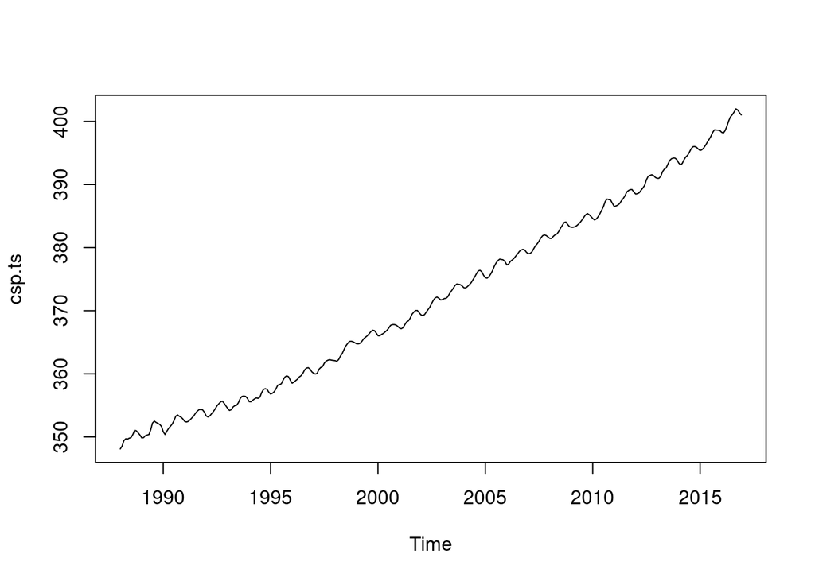

```r
plot(csp.ts,type='l')
```

Looking at the observed data, we can see that there is an upward trend, where the amplitude of seasonality doesn’t vary with the height of the trend. This looks like an additive relationship. So we definitely have seaonality, and there is a trend.

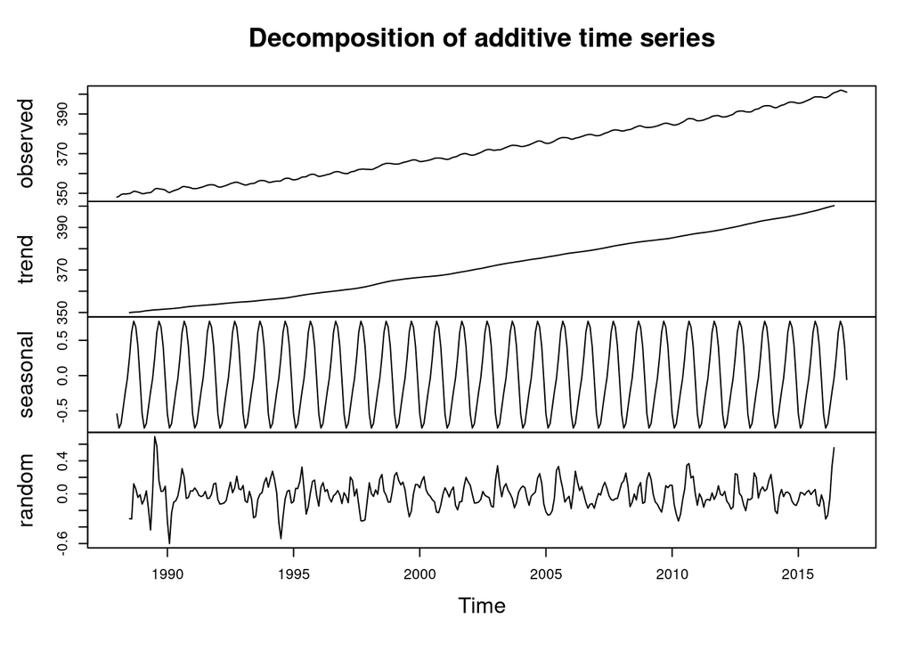

```r
plot(decompose(csp.ts))
```

Looking at the random data, it seems like our randomness is also constant over, and with this, we will not have to transform the data.

The plan out of the gate is to look at a: Linear model (GLS) Seas(Harmonic) w/ ARIMA for Autocorrs. Linear model (GLS) Seas(Indicator) w/ ARIMA for Autocorrs. Holt Winters SARIMA

Finally, we will use a test / train split to compare our overall performance of our models.

So first, lets split our data. The training set has the first 26 years while the test set will contain the last 3 that we will compare our models with.

```r
csp.tr = window(csp.ts,end=c(2013,12))
csp.test = window(csp.ts,st=c(2014,1))
```

FITTING MODELS: LINEAR REGRESSIVE INDICATOR/FACTOR MODEL

We will start off by standardizing TIME and getting the Seasonal factors

```r
TIME = 1:length(csp.tr)
Seas = cycle(csp.tr)
```

Looking at the decomposed trend, we can see that it is fairly linear. But I will add up to TIME^4 for predictors.

```r
csp.tr.ind = lm(csp.tr~0+TIME+I(TIME^2)+I(TIME^3)+I(TIME^4)+factor(Seas))
```

Now lets look at the summary

```r
summary(csp.tr.ind)
```

```
##
## Call:
## lm(formula = csp.tr ~ 0 + TIME + I(TIME^2) + I(TIME^3) + I(TIME^4) +
##     factor(Seas))
##
## Residuals:
##      Min       1Q   Median       3Q      Max
## -1.34096 -0.30252 -0.03035  0.28907  0.89750
##
## Coefficients:
##                  Estimate Std. Error  t value Pr(>|t|)
## TIME            4.179e-02  4.866e-03    8.588 5.12e-16 ***
## I(TIME^2)       7.438e-04  6.306e-05   11.795  < 2e-16 ***
## I(TIME^3)      -2.086e-06  3.025e-07   -6.896 3.23e-11 ***
## I(TIME^4)       2.234e-09  4.794e-10    4.660 4.79e-06 ***
## factor(Seas)1   3.494e+02  1.302e-01 2683.306  < 2e-16 ***
## factor(Seas)2   3.492e+02  1.305e-01 2675.766  < 2e-16 ***
## factor(Seas)3   3.493e+02  1.308e-01 2670.545  < 2e-16 ***
## factor(Seas)4   3.495e+02  1.311e-01 2666.543  < 2e-16 ***
## factor(Seas)5   3.497e+02  1.313e-01 2662.699  < 2e-16 ***
## factor(Seas)6   3.499e+02  1.316e-01 2659.147  < 2e-16 ***
## factor(Seas)7   3.503e+02  1.318e-01 2656.934  < 2e-16 ***
## factor(Seas)8   3.506e+02  1.320e-01 2655.287  < 2e-16 ***
## factor(Seas)9   3.508e+02  1.322e-01 2652.418  < 2e-16 ***
## factor(Seas)10  3.507e+02  1.324e-01 2648.093  < 2e-16 ***
## factor(Seas)11  3.504e+02  1.326e-01 2642.588  < 2e-16 ***
## factor(Seas)12  3.500e+02  1.328e-01 2635.848  < 2e-16 ***
## ---
## Signif. codes:  0 '***' 0.001 '**' 0.01 '*' 0.05 '.' 0.1 ' ' 1
##
## Residual standard error: 0.382 on 296 degrees of freedom
## Multiple R-squared:      1,  Adjusted R-squared:      1
## F-statistic: 1.823e+07 on 16 and 296 DF,  p-value: < 2.2e-16
```

Every predictor was significant

Lets fit a GLS to remove fake significant predictors.

Estimate the AR coefficient in order to start. This AR Coefficient will roughly account for the autocorrelation when it is put into the GLS function

```r
csp.tr.ind.ar = ar(resid(csp.tr.ind),order.max=1)
csp.tr.ind.ar$ar
```

```
## [1] 0.8850705
```

We have .89

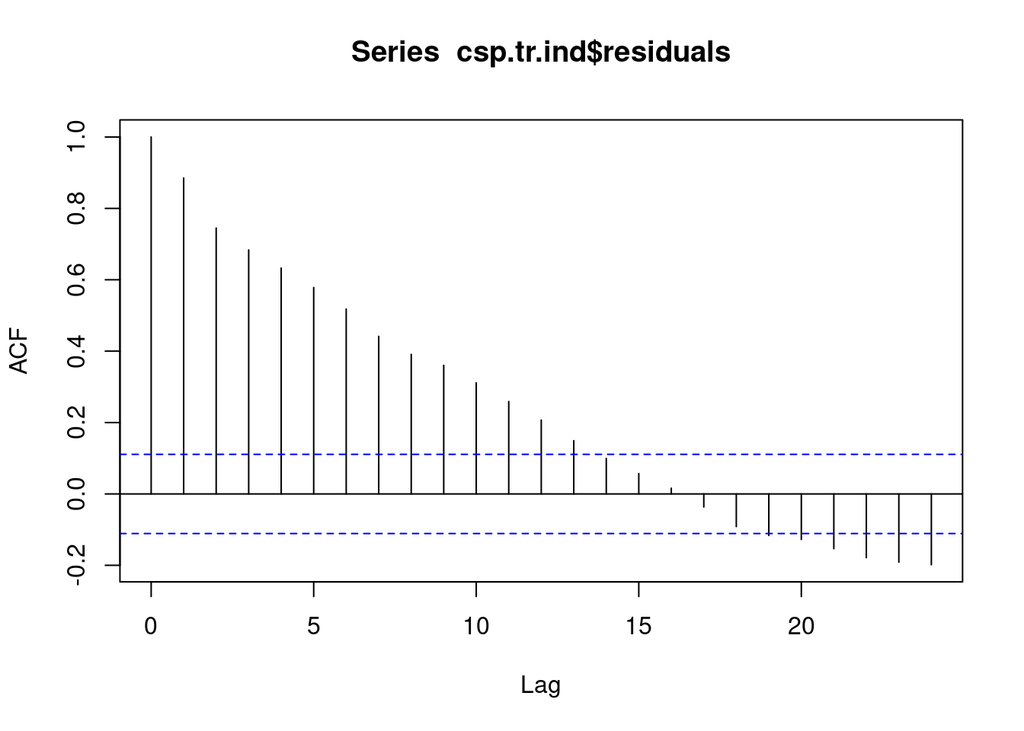

```r
acf(csp.tr.ind$residuals)
```

Lets fit the GLS with a quick brute force stepwise!

```r
csp.tr.ind.gls = gls(csp.tr~0+TIME+I(TIME^2)+I(TIME^3)+I(TIME^4)+factor(Seas),cor=corARMA(c(0.8850705),p=1,q=0))
summary(csp.tr.ind.gls)
```

```
## Generalized least squares fit by REML
##   Model: csp.tr ~ 0 + TIME + I(TIME^2) + I(TIME^3) + I(TIME^4) + factor(Seas)
##   Data: NULL
##         AIC       BIC   logLik
##   -97.58039 -31.15392 66.79019
##
## Correlation Structure: AR(1)
##  Formula: ~1
##  Parameter estimate(s):
##      Phi
## 0.999992
##
## Coefficients:
##                   Value Std.Error   t-value p-value
## TIME             0.1048   0.03663  2.860403  0.0045
## I(TIME^2)        0.0001   0.00051  0.219944  0.8261
## I(TIME^3)        0.0000   0.00000  0.038710  0.9691
## I(TIME^4)        0.0000   0.00000 -0.025910  0.9793
## factor(Seas)1  347.9951  39.47054  8.816578  0.0000
## factor(Seas)2  347.8275  39.47055  8.812330  0.0000
## factor(Seas)3  347.9177  39.47056  8.814613  0.0000
## factor(Seas)4  348.1238  39.47057  8.819832  0.0000
## factor(Seas)5  348.3085  39.47058  8.824510  0.0000
## factor(Seas)6  348.4898  39.47058  8.829103  0.0000
## factor(Seas)7  348.8066  39.47058  8.837129  0.0000
## factor(Seas)8  349.1585  39.47058  8.846045  0.0000
## factor(Seas)9  349.3098  39.47058  8.849878  0.0000
## factor(Seas)10 349.2296  39.47057  8.847848  0.0000
## factor(Seas)11 348.9542  39.47056  8.840872  0.0000
## factor(Seas)12 348.4765  39.47055  8.828773  0.0000
##
##  Correlation:
##                TIME   I(TIME^2 I(TIME^3 I(TIME^4 fc(S)1 fc(S)2 fc(S)3 fc(S)4
## I(TIME^2)      -0.872
## I(TIME^3)       0.754 -0.969
## I(TIME^4)      -0.672  0.918   -0.986
## factor(Seas)1  -0.009  0.001   -0.001    0.001
## factor(Seas)2  -0.010  0.001   -0.001    0.001    1.000
## factor(Seas)3  -0.010  0.001   -0.001    0.001    1.000  1.000
## factor(Seas)4  -0.010  0.001   -0.001    0.001    1.000  1.000  1.000
```

[output cut: 16 more lines]

```
## factor(Seas)5
## factor(Seas)6   1.000
## factor(Seas)7   1.000  1.000
## factor(Seas)8   1.000  1.000  1.000
## factor(Seas)9   1.000  1.000  1.000  1.000
## factor(Seas)10  1.000  1.000  1.000  1.000  1.000
## factor(Seas)11  1.000  1.000  1.000  1.000  1.000  1.000
## factor(Seas)12  1.000  1.000  1.000  1.000  1.000  1.000  1.000
##
## Standardized residuals:
##          Min           Q1          Med           Q3          Max
## -0.038531455 -0.012968377  0.001285668  0.012723759  0.034505195
##
## Residual standard error: 39.47021
## Degrees of freedom: 312 total; 296 residual
```

```r
csp.tr.ind.gls = gls(csp.tr~0+TIME+I(TIME^2)+I(TIME^3)+factor(Seas),cor=corARMA(c(0.8850705),p=1,q=0))
summary(csp.tr.ind.gls)
```

```
## Generalized least squares fit by REML
##   Model: csp.tr ~ 0 + TIME + I(TIME^2) + I(TIME^3) + factor(Seas)
##   Data: NULL
##         AIC       BIC   logLik
##   -136.4554 -73.66194 85.22769
##
## Correlation Structure: AR(1)
##  Formula: ~1
##  Parameter estimate(s):
##       Phi
## 0.9912301
##
## Coefficients:
##                   Value Std.Error   t-value p-value
## TIME             0.1024 0.0242780   4.21617  0.0000
## I(TIME^2)        0.0001 0.0001852   0.75170  0.4528
## I(TIME^3)        0.0000 0.0000004  -0.00346  0.9972
## factor(Seas)1  348.0089 1.1944753 291.34879  0.0000
## factor(Seas)2  347.8414 1.1948295 291.12217  0.0000
## factor(Seas)3  347.9316 1.1951200 291.12690  0.0000
## factor(Seas)4  348.1377 1.1953468 291.24410  0.0000
## factor(Seas)5  348.3224 1.1955097 291.35888  0.0000
## factor(Seas)6  348.5037 1.1956089 291.48637  0.0000
## factor(Seas)7  348.8205 1.1956442 291.74273  0.0000
## factor(Seas)8  349.1724 1.1956158 292.04401  0.0000
## factor(Seas)9  349.3237 1.1955235 292.19307  0.0000
## factor(Seas)10 349.2435 1.1953675 292.16414  0.0000
## factor(Seas)11 348.9681 1.1951477 291.98739  0.0000
## factor(Seas)12 348.4904 1.1948642 291.65691  0.0000
##
##  Correlation:
##                TIME   I(TIME^2 I(TIME^3 fc(S)1 fc(S)2 fc(S)3 fc(S)4 fc(S)5
## I(TIME^2)      -0.914
## I(TIME^3)       0.812 -0.974
## factor(Seas)1  -0.423  0.191   -0.117
## factor(Seas)2  -0.423  0.192   -0.117    1.000
## factor(Seas)3  -0.423  0.192   -0.117    0.999  1.000
## factor(Seas)4  -0.423  0.192   -0.117    0.999  0.999  1.000
## factor(Seas)5  -0.424  0.192   -0.117    0.999  0.999  0.999  1.000
## factor(Seas)6  -0.424  0.192   -0.117    0.999  0.999  0.999  0.999  1.000
```

[output cut: 13 more lines]

```
## factor(Seas)5
## factor(Seas)6
## factor(Seas)7   1.000
## factor(Seas)8   0.999  1.000
## factor(Seas)9   0.999  0.999  1.000
## factor(Seas)10  0.999  0.999  0.999  1.000
## factor(Seas)11  0.999  0.999  0.999  0.999  1.000
## factor(Seas)12  0.999  0.999  0.999  0.999  0.999  1.000
##
## Standardized residuals:
##         Min          Q1         Med          Q3         Max
## -1.24522488 -0.43080036  0.03376418  0.40333894  1.16852062
##
## Residual standard error: 1.18474
## Degrees of freedom: 312 total; 297 residual
```

```r
csp.tr.ind.gls = gls(csp.tr~0+TIME+I(TIME^2)+factor(Seas),cor=corARMA(c(0.8850705),p=1,q=0))
summary(csp.tr.ind.gls)
```

```
## Generalized least squares fit by REML
##   Model: csp.tr ~ 0 + TIME + I(TIME^2) + factor(Seas)
##   Data: NULL
##         AIC       BIC   logLik
##   -166.4033 -107.2498 99.20166
##
## Correlation Structure: AR(1)
##  Formula: ~1
##  Parameter estimate(s):
##     Phi
## 0.97816
##
## Coefficients:
##                   Value Std.Error  t-value p-value
## TIME             0.1023 0.0100119  10.2170       0
## I(TIME^2)        0.0001 0.0000304   4.5608       0
## factor(Seas)1  348.0238 0.7150189 486.7338       0
## factor(Seas)2  347.8563 0.7154747 486.1895       0
## factor(Seas)3  347.9465 0.7158483 486.0618       0
## factor(Seas)4  348.1526 0.7161391 486.1523       0
## factor(Seas)5  348.3373 0.7163459 486.2697       0
## factor(Seas)6  348.5186 0.7164681 486.4398       0
## factor(Seas)7  348.8354 0.7165046 486.8572       0
## factor(Seas)8  349.1874 0.7164544 487.3825       0
## factor(Seas)9  349.3386 0.7163166 487.6875       0
## factor(Seas)10 349.2585 0.7160900 487.7299       0
## factor(Seas)11 348.9830 0.7157735 487.5607       0
## factor(Seas)12 348.5053 0.7153660 487.1707       0
##
##  Correlation:
##                TIME   I(TIME fc(S)1 fc(S)2 fc(S)3 fc(S)4 fc(S)5 fc(S)6 fc(S)7
## I(TIME^2)      -0.951
## factor(Seas)1  -0.725  0.543
## factor(Seas)2  -0.725  0.544  0.999
## factor(Seas)3  -0.726  0.544  0.998  0.999
## factor(Seas)4  -0.726  0.544  0.998  0.998  0.999
## factor(Seas)5  -0.726  0.545  0.998  0.998  0.998  0.999
## factor(Seas)6  -0.726  0.545  0.997  0.998  0.998  0.998  0.999
## factor(Seas)7  -0.726  0.545  0.997  0.997  0.998  0.998  0.998  0.999
## factor(Seas)8  -0.726  0.545  0.997  0.997  0.997  0.998  0.998  0.998  0.999
```

[output cut: 10 more lines]

```
## factor(Seas)5
## factor(Seas)6
## factor(Seas)7
## factor(Seas)8
## factor(Seas)9   0.999
## factor(Seas)10  0.998  0.999
## factor(Seas)11  0.998  0.998  0.999
## factor(Seas)12  0.998  0.998  0.998  0.999
##
## Standardized residuals:
##         Min          Q1         Med          Q3         Max
## -1.97957319 -0.67763070  0.05366125  0.63558645  1.83041963
##
## Residual standard error: 0.7489613
## Degrees of freedom: 312 total; 298 residual
```

TIME^2 is significant when TIME^3 is removed

```r
csp.tr.ind = lm(csp.tr~0+TIME+I(TIME^2)+factor(Seas))
```

We will look at the residuals to see if there is any remaining structure

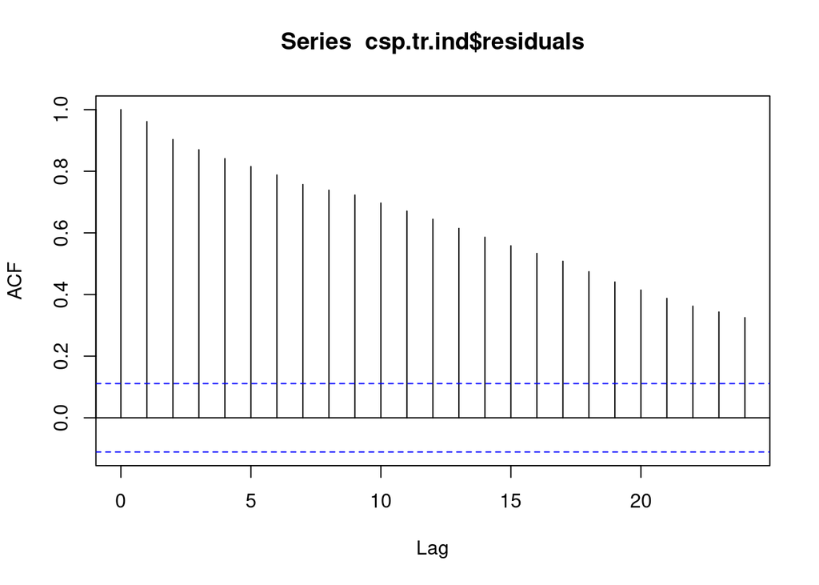

```r
acf(csp.tr.ind$residuals)
```

As we can see, there are still a ton of significant lags / autocorrelation